# Goal of the project

The goal of the project is to identify the persons of interest in Enron scandal if a new dataset is given.We are aiming to build a POI idenfier model using the current dataset by Supervised learning. Depending on how we choose the features and amount of data available, Machine learning gives us a predictive model which can be used on other datasets with certain level of accuracy.

The information available in the dataset is the different types of payment given to the insiders, email details, & POI identifier for a list of insiders.

Machine Learning helps us identify patterns in the data and relevance of the selected features in predicting the outcome and brings out hidden insights in the data. There are various algorithms avalaible in Machine learning and which one to use depends on the dataset given and the amount of data.

As mentioned earlier there are financial as well as email information for different insiders. Understanding the different features available is the first task of Machine Learning.

# Characteristics of the Dataset

```python
import sys
import pickle
import matplotlib.pyplot
sys.path.append("../tools/")
with open("final_project_dataset.pkl", "r") as data_file:
    data_dict = pickle.load(data_file)
import pandas as pd
data_df=pd.DataFrame(data_dict).T
data_df.shape
#146 x 21
data_df[data_df['poi']==1]['poi'].count()
#18
data_df[data_df['poi']==0]['poi'].count()
#128
for column in data_df:
    print column, data_df[data_df[column]=='NaN'][column].count()
#bonus 64
#deferral_payments 107
#deferred_income 97
#director_fees 129
#email_address 35
#exercised_stock_options 44
#expenses 51
#from_messages 60
#from_poi_to_this_person 60
#from_this_person_to_poi 60
#loan_advances 142
#long_term_incentive 80
#other 53
#poi 0
#restricted_stock 36
#restricted_stock_deferred 128
#salary 51
#shared_receipt_with_poi 60
#to_messages 60
#total_payments 21
#total_stock_value 20
```

```
bonus 64
deferral_payments 107
deferred_income 97
director_fees 129
email_address 35
exercised_stock_options 44
expenses 51
from_messages 60
from_poi_to_this_person 60
from_this_person_to_poi 60
loan_advances 142
long_term_incentive 80
other 53
poi 0
restricted_stock 36
restricted_stock_deferred 128
salary 51
shared_receipt_with_poi 60
to_messages 60
total_payments 21
total_stock_value 20
```

There are 146 rows in the dataset with 21 features. We also see that out of given data of 146 insiders, we have only 18 insiders being identified as POI. This is a highly imbalanced dataset.

If we see the number of missing values for each column, loan_advances has 142 missing values while the total number of rows are 146. This suggests that loan_advances cannot be used as a feature in our prediction.Likewise restricted_stock_deferred(128 missing values) may not be useful.

# exercised_stock_options

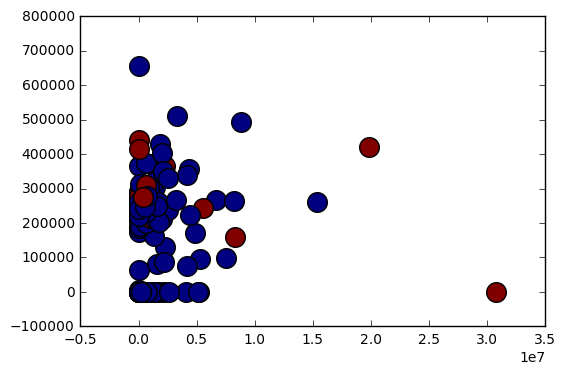

```python
for point in data:
             salary = point[1]
             exercised_stock_options = point[4]
             poi=point[0]
             matplotlib.pyplot.scatter(exercised_stock_options, salary,c=poi,s=200,norm=matplotlib.colors.SymLogNorm(linthresh=10, vmin=0, vmax=1))
matplotlib.pyplot.show()
```

```python
import pandas as pd
data_df=pd.DataFrame(data_dict).T
data_df.loc[data_df['exercised_stock_options']>3e+08]
```

|  | IsDirector | TotalPayments-Salary | bonus | deferral_payments | deferred_income | director_fees | email_address | exercised_stock_options | expenses | from_messages | ... | other | poi | restricted_stock | restricted_stock_deferred | salary | shared_receipt_with_poi | to_messages | to_messages_ratio | total_payments | total_stock_value |
| --- | --- | --- | --- | --- | --- | --- | --- | --- | --- | --- | --- | --- | --- | --- | --- | --- | --- | --- | --- | --- | --- |
| BAY FRANKLIN R | 0 | 3.45347 | 400000 | 260455 | -201641 | NaN | frank.bay@enron.com | NaN | 129142 | NaN | ... | 69 | False | 145796 | -82782 | 239671 | NaN | NaN | 0 | 827696 | 63014 |
| BECK SALLY W | 0 | 4.18912 | 700000 | NaN | NaN | NaN | sally.beck@enron.com | NaN | 37172 | 4343 | ... | 566 | False | 126027 | NaN | 231330 | 2639 | 7315 | 0.0196856 | 969068 | 126027 |
| BERGSIEKER RICHARD P | 0 | 3.29312 | 250000 | NaN | -485813 | NaN | rick.bergsieker@enron.com | NaN | 59175 | 59 | ... | 427316 | False | 659249 | NaN | 187922 | 233 | 383 | 0.0104439 | 618850 | 659249 |
| BLAKE JR. NORMAN P | 1 | 0 | NaN | NaN | -113784 | 113784 | NaN | NaN | 1279 | NaN | ... | NaN | False | NaN | NaN | NaN | NaN | NaN | 0 | 1279 | NaN |
| BOWEN JR RAYMOND M | 0 | 9.58212 | 1350000 | NaN | -833 | NaN | raymond.bowen@enron.com | NaN | 65907 | 27 | ... | 1621 | True | 252055 | NaN | 278601 | 1593 | 1858 | 0.0753498 | 2669589 | 252055 |
| BROWN MICHAEL | 0 | 0 | NaN | NaN | NaN | NaN | michael.brown@enron.com | NaN | 49288 | 41 | ... | NaN | False | NaN | NaN | NaN | 761 | 1486 | 0.00874832 | 49288 | NaN |
| BUTTS ROBERT H | 0 | 4.86235 | 750000 | NaN | -75000 | NaN | bob.butts@enron.com | NaN | 9410 | NaN | ... | 150656 | False | 417619 | NaN | 261516 | NaN | NaN | 0 | 1271582 | 417619 |
| CALGER CHRISTOPHER F | 0 | 6.82503 | 1250000 | NaN | -262500 | NaN | christopher.calger@enron.com | NaN | 35818 | 144 | ... | 486 | True | 126027 | NaN | 240189 | 2188 | 2598 | 0.0765974 | 1639297 | 126027 |
| CARTER REBECCA C | 0 | 1.82407 | 300000 | NaN | -159792 | NaN | rebecca.carter@enron.com | NaN | NaN | 15 | ... | 540 | False | 307301 | -307301 | 261809 | 196 | 312 | 0.0929487 | 477557 | NaN |
| CAUSEY RICHARD A | 0 | 4.50098 | 1000000 | NaN | -235000 | NaN | richard.causey@enron.com | NaN | 30674 | 49 | ... | 307895 | True | 2502063 | NaN | 415189 | 1585 | 1892 | 0.0306554 | 1868758 | 2502063 |
| CHAN RONNIE | 1 | 0 | NaN | NaN | -98784 | 98784 | NaN | NaN | NaN | NaN | ... | NaN | False | 32460 | -32460 | NaN | NaN | NaN | 0 | NaN | NaN |
| CLINE KENNETH W | 0 | 0 | NaN | NaN | NaN | NaN | NaN | NaN | NaN | NaN | ... | NaN | False | 662086 | -472568 | NaN | NaN | NaN | 0 | NaN | 189518 |
| COLWELL WESLEY | 0 | 5.16509 | 1200000 | 27610 | -144062 | NaN | wes.colwell@enron.com | NaN | 16514 | 40 | ... | 101740 | True | 698242 | NaN | 288542 | 1132 | 1758 | 0.136519 | 1490344 | 698242 |
| CUMBERLAND MICHAEL S | 0 | 4.36972 | 325000 | NaN | NaN | NaN | NaN | NaN | 22344 | NaN | ... | 713 | False | 207940 | NaN | 184899 | NaN | NaN | 0 | 807956 | 207940 |
| DODSON KEITH | 0 | 1.44768 | 70000 | NaN | NaN | NaN | keith.dodson@enron.com | NaN | 28164 | 14 | ... | 774 | False | NaN | NaN | 221003 | 114 | 176 | 0.0568182 | 319941 | NaN |
| FASTOW ANDREW S | 0 | 5.50055 | 1300000 | NaN | -1386055 | NaN | andrew.fastow@enron.com | NaN | 55921 | NaN | ... | 277464 | True | 1794412 | NaN | 440698 | NaN | NaN | 0 | 2424083 | 1794412 |
| GRAMM WENDY L | 1 | 0 | NaN | NaN | NaN | 119292 | NaN | NaN | NaN | NaN | ... | NaN | False | NaN | NaN | NaN | NaN | NaN | 0 | 119292 | NaN |
| GRAY RODNEY | 0 | 173.342 | NaN | 93585 | NaN | NaN | NaN | NaN | NaN | NaN | ... | 680833 | False | NaN | NaN | 6615 | NaN | NaN | 0 | 1146658 | NaN |
| HAUG DAVID L | 0 | 0 | NaN | NaN | NaN | NaN | david.haug@enron.com | NaN | 475 | 19 | ... | NaN | False | 2217299 | NaN | NaN | 471 | 573 | 0.0069808 | 475 | 2217299 |
| HAYES ROBERT E | 0 | 0 | NaN | 7961 | NaN | NaN | robert.hayes@enron.com | NaN | NaN | 12 | ... | NaN | False | 151418 | NaN | NaN | 50 | 504 | 0.031746 | 7961 | 151418 |
| HAYSLETT RODERICK J | 0 | 0 | NaN | NaN | NaN | NaN | rod.hayslett@enron.com | NaN | NaN | 1061 | ... | NaN | False | 346663 | NaN | NaN | 571 | 2649 | 0.0132125 | NaN | 346663 |
| HICKERSON GARY J | 0 | 9.82962 | 1700000 | NaN | NaN | NaN | gary.hickerson@enron.com | NaN | 98849 | 27 | ... | 1936 | False | 441096 | NaN | 211788 | 900 | 1320 | 0.030303 | 2081796 | 441096 |
| KISHKILL JOSEPH G | 0 | 4.04541 | NaN | NaN | -51042 | NaN | joe.kishkill@enron.com | NaN | 116335 | NaN | ... | 465357 | False | 1034346 | NaN | 174246 | NaN | NaN | 0 | 704896 | 1034346 |
| KOPPER MICHAEL J | 0 | 11.8259 | 800000 | NaN | NaN | NaN | michael.kopper@enron.com | NaN | 118134 | NaN | ... | 907502 | True | 985032 | NaN | 224305 | NaN | NaN | 0 | 2652612 | 985032 |
| LEFF DANIEL P | 0 | 9.73248 | 1000000 | NaN | NaN | NaN | dan.leff@enron.com | NaN | NaN | 63 | ... | 3083 | False | 360528 | NaN | 273746 | 2672 | 2822 | 0.023742 | 2664228 | 360528 |
| LOCKHART EUGENE E | 0 | 0 | NaN | NaN | NaN | NaN | NaN | NaN | NaN | NaN | ... | NaN | False | NaN | NaN | NaN | NaN | NaN | 0 | NaN | NaN |
| MENDELSOHN JOHN | 1 | 0 | NaN | NaN | -103750 | 103750 | NaN | NaN | 148 | NaN | ... | NaN | False | NaN | NaN | NaN | NaN | NaN | 0 | 148 | NaN |
| METTS MARK | 0 | 2.90285 | 600000 | NaN | NaN | NaN | mark.metts@enron.com | NaN | 94299 | 29 | ... | 1740 | False | 585062 | NaN | 365788 | 702 | 807 | 0.047088 | 1061827 | 585062 |
| MEYER JEROME J | 1 | 0 | NaN | NaN | -38346 | 38346 | NaN | NaN | 2151 | NaN | ... | NaN | False | NaN | NaN | NaN | NaN | NaN | 0 | 2151 | NaN |
| MORDAUNT KRISTINA M | 0 | 2.3532 | 325000 | NaN | NaN | NaN | kristina.mordaunt@enron.com | NaN | 35018 | NaN | ... | 1411 | False | 208510 | NaN | 267093 | NaN | NaN | 0 | 628522 | 208510 |
| NOLES JAMES L | 0 | 0 | NaN | 774401 | NaN | NaN | NaN | NaN | NaN | NaN | ... | NaN | False | 463261 | -94556 | NaN | NaN | NaN | 0 | 774401 | 368705 |
| PEREIRA PAULO V. FERRAZ | 1 | 0 | NaN | NaN | -101250 | 101250 | NaN | NaN | 27942 | NaN | ... | NaN | False | NaN | NaN | NaN | NaN | NaN | 0 | 27942 | NaN |
| PIRO JIM | 0 | 0 | NaN | NaN | NaN | NaN | jim.piro@enron.com | NaN | NaN | 16 | ... | NaN | False | 47304 | NaN | NaN | 3 | 58 | 0 | NaN | 47304 |
| POWERS WILLIAM | 1 | 0 | NaN | NaN | -17500 | 17500 | ken.powers@enron.com | NaN | NaN | 26 | ... | NaN | False | NaN | NaN | NaN | 12 | 653 | 0 | NaN | NaN |
| SAVAGE FRANK | 1 | 0 | NaN | NaN | -121284 | 125034 | NaN | NaN | NaN | NaN | ... | NaN | False | NaN | NaN | NaN | NaN | NaN | 0 | 3750 | NaN |
| STABLER FRANK | 0 | 4.64333 | 500000 | NaN | NaN | NaN | frank.stabler@enron.com | NaN | 16514 | NaN | ... | 356071 | False | 511734 | NaN | 239502 | NaN | NaN | 0 | 1112087 | 511734 |
| SUNDE MARTIN | 0 | 6.00056 | 700000 | NaN | NaN | NaN | marty.sunde@enron.com | NaN | NaN | 38 | ... | 111122 | False | 698920 | NaN | 257486 | 2565 | 2647 | 0.0139781 | 1545059 | 698920 |
| THE TRAVEL AGENCY IN THE PARK | 0 | 0 | NaN | NaN | NaN | NaN | NaN | NaN | NaN | NaN | ... | 362096 | False | NaN | NaN | NaN | NaN | NaN | 0 | 362096 | NaN |
| TOTAL | 1 | 11.6044 | 97343619 | 32083396 | -27992891 | 1398517 | NaN | 311764000 | 5235198 | NaN | ... | 42667589 | False | 130322299 | -7576788 | 26704229 | NaN | NaN | 0 | 309886585 | 434509511 |
| UMANOFF ADAM S | 0 | 3.9172 | 788750 | NaN | NaN | NaN | adam.umanoff@enron.com | NaN | 53122 | 18 | ... | NaN | False | NaN | NaN | 288589 | 41 | 111 | 0.108108 | 1130461 | NaN |
| URQUHART JOHN A | 1 | 0 | NaN | NaN | -36666 | 36666 | NaN | NaN | 228656 | NaN | ... | NaN | False | NaN | NaN | NaN | NaN | NaN | 0 | 228656 | NaN |
| WAKEHAM JOHN | 1 | 0 | NaN | NaN | NaN | 109298 | NaN | NaN | 103773 | NaN | ... | NaN | False | NaN | NaN | NaN | NaN | NaN | 0 | 213071 | NaN |
| WESTFAHL RICHARD K | 0 | 11.9562 | NaN | NaN | -10800 | NaN | dick.westfahl@enron.com | NaN | 51870 | NaN | ... | 401130 | False | 384930 | NaN | 63744 | NaN | NaN | 0 | 762135 | 384930 |
| WINOKUR JR. HERBERT S | 1 | 0 | NaN | NaN | -25000 | 108579 | NaN | NaN | 1413 | NaN | ... | NaN | False | NaN | NaN | NaN | NaN | NaN | 0 | 84992 | NaN |
| WODRASKA JOHN | 0 | 0 | NaN | NaN | NaN | NaN | john.wodraska@enron.com | NaN | NaN | NaN | ... | 189583 | False | NaN | NaN | NaN | NaN | NaN | 0 | 189583 | NaN |

45 rows × 25 columns

# Non-Individuals

```python
import pandas as pd
data_df=pd.DataFrame(data_dict).T
data_df.loc[(data_df['other'])==(data_df['total_payments'])].loc[(data_df['total_payments'])!="NaN"]
```

|  | IsDirector | TotalPayments-Salary | bonus | deferral_payments | deferred_income | director_fees | email_address | exercised_stock_options | expenses | from_messages | ... | other | poi | restricted_stock | restricted_stock_deferred | salary | shared_receipt_with_poi | to_messages | to_messages_ratio | total_payments | total_stock_value |
| --- | --- | --- | --- | --- | --- | --- | --- | --- | --- | --- | --- | --- | --- | --- | --- | --- | --- | --- | --- | --- | --- |
| THE TRAVEL AGENCY IN THE PARK | 0 | 0 | NaN | NaN | NaN | NaN | NaN | NaN | NaN | NaN | ... | 362096 | False | NaN | NaN | NaN | NaN | NaN | 0 | 362096 | NaN |
| WODRASKA JOHN | 0 | 0 | NaN | NaN | NaN | NaN | john.wodraska@enron.com | NaN | NaN | NaN | ... | 189583 | False | NaN | NaN | NaN | NaN | NaN | 0 | 189583 | NaN |

2 rows × 25 columns

We are trying to find out if there any entries which are not corresponding to individuals in the company. If all payments except for under category 'other' are not given, there is a high chance that the row is not related to an individual. Thus we found 'The Travel Agency In The Park' which should be removed from the dataset

# CEOs of the Company

The payments to high level management is always extreme and it often skews the data. So it is better to remove the persons whose salary is greater than 1e6

```python
data_df.loc[(data_df['salary'])>1000000].loc[(data_df['salary'])!="NaN"]
```

|  | IsDirector | TotalPayments-Salary | bonus | deferral_payments | deferred_income | director_fees | email_address | exercised_stock_options | expenses | from_messages | ... | other | poi | restricted_stock | restricted_stock_deferred | salary | shared_receipt_with_poi | to_messages | to_messages_ratio | total_payments | total_stock_value |
| --- | --- | --- | --- | --- | --- | --- | --- | --- | --- | --- | --- | --- | --- | --- | --- | --- | --- | --- | --- | --- | --- |
| FREVERT MARK A | 0 | 16.2617 | 2000000 | 6426990 | -3367011 | NaN | mark.frevert@enron.com | 10433518 | 86987 | 21 | ... | 7427621 | False | 4188667 | NaN | 1060932 | 2979 | 3275 | 0.0738931 | 17252530 | 14622185 |
| LAY KENNETH L | 0 | 96.5754 | 7000000 | 202911 | -300000 | NaN | kenneth.lay@enron.com | 34348384 | 99832 | 36 | ... | 10359729 | True | 14761694 | NaN | 1072321 | 2411 | 4273 | 0.0287854 | 103559793 | 49110078 |
| SKILLING JEFFREY K | 0 | 7.81341 | 5600000 | NaN | NaN | NaN | jeff.skilling@enron.com | 19250000 | 29336 | 108 | ... | 22122 | True | 6843672 | NaN | 1111258 | 2042 | 3627 | 0.0242625 | 8682716 | 26093672 |
| TOTAL | 1 | 11.6044 | 97343619 | 32083396 | -27992891 | 1398517 | NaN | 311764000 | 5235198 | NaN | ... | 42667589 | False | 130322299 | -7576788 | 26704229 | NaN | NaN | 0 | 309886585 | 434509511 |

4 rows × 25 columns

# Feature Selection

Some of the features given are modified to better represent the scenario like to_messages_ratio & from_messages_ratio which gives a ratio of emails sent to POIs or from POIs in the total amount of resepctive emails (from or to). Also another feature is added which is IsDirector to represent whether a particular insider is a director or not depending on whether that particular insider is given director fees or not. This has been done on the hypothesis that directors have more chance to be a POI as they have higher influence in taking company decissions. As we are taking IsDirector feature, I opted to remove director_fees feature as it kind of becomes redundant. Nothing much can be drawn from resticted stock features or deferal payments and are opted to be left in the features list. SelectKbest is then used on the new set features to filter out 10 best features.

Feature scores using SelectKbest are as given below:

[('salary', '9.08', '0.003'), ('bonus', '8.42', '0.004'), ('long_term_incentive', '3.30', '0.071'), ('deferred_income', '17.82', '0.000'), ('deferral_payments', '0.06', '0.804'), ('other', '0.53', '0.468'), ('expenses', '5.30', '0.023'), ('IsDirector', '2.19', '0.141'), ('total_payments', '2.48', '0.117'), ('exercised_stock_options', '11.57', '0.001'), ('restricted_stock', '1.11', '0.295'), ('to_messages_ratio', '3.35', '0.069'), ('from_messages_ratio', '12.97', '0.000')]

The features that are finally selected for the prediction are : Salary, bonus, long_term_incetive, deferred_income, expenses, IsDirector, total_payments, exercised_stock_options, to_messages_ratio, from_messages_ratio

Why Chi2 or f_classif :

Chi2 is mainly used for categorical data and as we see that our dataset contains lot numberical data, I opt to use f_classif

# Feature Scaling

Feature Scaling is not used in the prediction, as the alogorithms used are NaiveBayes & Decision Trees

# Algorithms Used

NaiveBayes & Decision Tree are chosen for the prediction. NaiveBayes algorithm by its nature does not require any parameter input. As Decision trees often tend to be overfitting if not optimized properly, we need chose our parameters accordingly.

# Parameter Tuning

Naive Bayes does not require any parameters and hence there is no need for parameter tuning in this case.

But when opted to use different parameter values than the default values for min_samples_split and min_samples_leaf, the recall value drops down by almost 50%.

# Validation

After the model is trained on a part of the dataset given, it needs to be tested on the other part as a validation to see if the model is giving required level of accuracy, precision and recall

Depending on the algorithm we choose, we need to select a suitable set of parameter values for the algorithm which is not always straight forward. In such cases after dividing the dataset into train and test sets, we further divide the train set into train set and validation set so that parameter selection can be tested on the validation set. Once the best parameter setting is chosen, the model is tested on the test set. If the test set is used in selecting the parameters and again later the same test set is used to test the model performance, the model may not be able to generalise to unseen data in this case.

# Evalulation Metrics

The dataset is divided into two datasets with 70% and 30% of data respectively. The model is being trained on the 70% of the data and tested on the other 30%

Given below is the performance of the two classifiers on the test data.

```
          Accuracy    Precision    Recall
```

NaiveBayes 0.84 0.43 0.33 DecisionTree 0.82 0.36 0.32

Precision of 0.43 shows that there if a person is classified as POI, there is 43% chance that the person is actually a POI. Recall of 0.33 shows that around 30% of the data which are actually POIs are classified as POIs.